# Actividad Integradora 2

Héctor Hibran Tapia Fernández - A01661114

2024-11-19

## Titanic

Base de datos del Titanic: Titanic.csv Base de datos de prueba: Titanic_test.csv

Las variables para la base de datos son las siguientes:

*Name:* Nombre del pasajero *PassengerId:* Ids del pasajero *Survived:* Si sobrevivió o no (No = 0, Sí = 1)  
*Ticket:* Número de ticket  
*Cabin:* Cabina en la que viajó  
*Pclass:* Clase en la que viajó (1 = 1era, 2 = 2da, 3 = 3ra)  
*Sex:* Masculino o Femenino (male/female)  
*Age:* Edad  
*SibSp:* Número de hermanos/conyuge a bordo  
*Parch:* Número de padres/hijos a bordo  
*Fare:* Tarifa que pagó  
*Embarked:* Puerto de embarcación (C = Cherbourg, Q = Queenstown, S = Southampton)

# 1. Prepara la base de datos Titanic:

```r
M = read.csv("Titanic.csv")
str(M)
```

```
## 'data.frame':    1309 obs. of  12 variables:
##  $ PassengerId: int  892 893 894 895 896 897 898 899 900 901 ...
##  $ Survived   : int  0 1 0 0 1 0 1 0 1 0 ...
##  $ Pclass     : int  3 3 2 3 3 3 3 2 3 3 ...
##  $ Name       : chr  "Kelly, Mr. James" "Wilkes, Mrs. James (Ellen Needs)" "Myles, Mr. Thomas Francis" "Wirz, Mr. Albert" ...
##  $ Sex        : chr  "male" "female" "male" "male" ...
##  $ Age        : num  34.5 47 62 27 22 14 30 26 18 21 ...
##  $ SibSp      : int  0 1 0 0 1 0 0 1 0 2 ...
##  $ Parch      : int  0 0 0 0 1 0 0 1 0 0 ...
##  $ Ticket     : chr  "330911" "363272" "240276" "315154" ...
##  $ Fare       : num  7.83 7 9.69 8.66 12.29 ...
##  $ Cabin      : chr  "" "" "" "" ...
##  $ Embarked   : chr  "Q" "S" "Q" "S" ...
```

## Ajustando las variables

*Variables de interés*: Quitamos aquellas variables que de entrada no tengan que ver con la sobrevivencia del pasajero. Variables 4, 9 y 11.

```r
M1 <- M[,c(-4,-9,-11)]
```

Ahora, las variables categóricas deben aparecer como factores: Survived, Pclass, Sex y Embarked

```r
for(var in c('Survived','Pclass','Embarked','Sex'))
  M1[,var] <-as.factor(M1[,var])
```

```r
#M
```

## Análisis de datos faltantes

Detectamos si hay espacios vacíos en lugar de datos:

```r
V = matrix(NA,ncol=1,nrow=9)
for(i in c(1:9)){
  V[i,] <- sum(with(M1,M1[,i])=="")}
V
```

```
##       [,1]
##  [1,]    0
##  [2,]    0
##  [3,]    0
##  [4,]    0
##  [5,]   NA
##  [6,]    0
##  [7,]    0
##  [8,]   NA
##  [9,]   NA
```

Ninguna variable tiene espacios vacíos, pero las variables 5 (Age), 8 (Fare) y 9 (Embarked) tienen datos faltantes.

Vamos a contar los datos faltantes:

```r
N = apply(X=is.na(M1),MARGIN = 2,FUN = sum)
P = round(100*N/length(M1[,2]),2)
NP = data.frame(as.numeric(N),as.numeric(P))
row.names(NP)= c("PassengerId", "Survived", "Pclass", "Sex", "Age", "SibSp", "Parch", "Fare", "Embarked")
names(NP)=c("Número","Porcentaje")
t(NP)
```

```
##            PassengerId Survived Pclass Sex    Age SibSp Parch Fare Embarked
## Número               0        0      0   0 263.00     0     0 1.00     2.00
## Porcentaje           0        0      0   0  20.09     0     0 0.08     0.15
```

En edad hay muchos datos faltantes, el 20% de los datos.

## Realiza un análisis descriptivo

Observemos el patrón de los datos faltantes:

```r
# install.packages("mice", type = "binary")
library("mice")
```

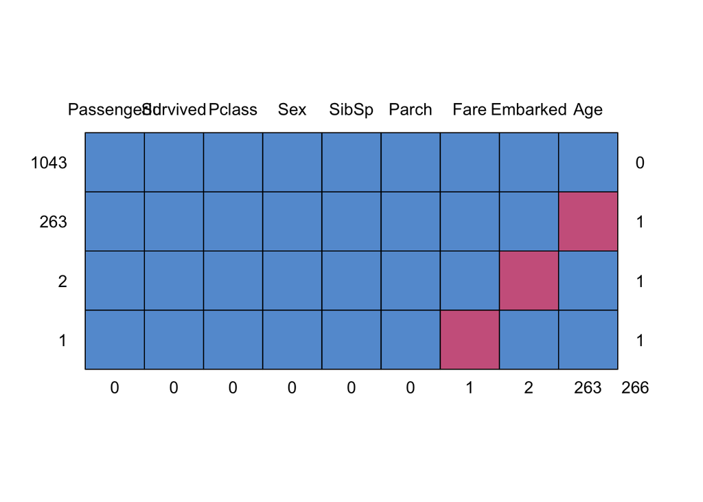

```
##      PassengerId Survived Pclass Sex SibSp Parch Fare Embarked Age
## 1043           1        1      1   1     1     1    1        1   1   0
## 263            1        1      1   1     1     1    1        1   0   1
## 2              1        1      1   1     1     1    1        0   1   1
## 1              1        1      1   1     1     1    0        1   1   1
##                0        0      0   0     0     0    1        2 263 266
```

```r
md.pattern(M1)
```

Todos los datos faltantes son de distintos pasajeros (observaciones), por lo tanto, si se eliminan los NA, se eliminarían 266 observaciones y nos quedaríamos con 1043 observaciones.

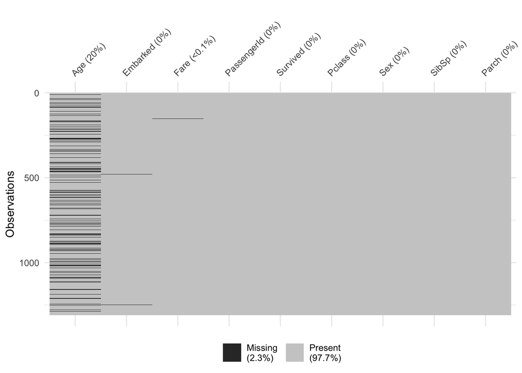

```r
#install.packages("naniar")
library(naniar)
vis_miss(M1,sort_miss = TRUE)
```

## Análisis sobre datos faltantes

*Medidas con datos faltantes*

```r
summary(M1[,-1])
```

```
##  Survived Pclass      Sex           Age            SibSp            Parch
##  0:815    1:323   female:466   Min.   : 0.17   Min.   :0.0000   Min.   :0.000
##  1:494    2:277   male  :843   1st Qu.:21.00   1st Qu.:0.0000   1st Qu.:0.000
##           3:709                Median :28.00   Median :0.0000   Median :0.000
##                                Mean   :29.88   Mean   :0.4989   Mean   :0.385
##                                3rd Qu.:39.00   3rd Qu.:1.0000   3rd Qu.:0.000
##                                Max.   :80.00   Max.   :8.0000   Max.   :9.000
##                                NA's   :263
##       Fare         Embarked
##  Min.   :  0.000   C   :270
##  1st Qu.:  7.896   Q   :123
##  Median : 14.454   S   :914
##  Mean   : 33.295   NA's:  2
##  3rd Qu.: 31.275
##  Max.   :512.329
##  NA's   :1
```

*Medidas sin datos faltantes*

```r
M2 = na.omit(M1)
summary(M2[,-1])
```

```
##  Survived Pclass      Sex           Age            SibSp
##  0:628    1:282   female:386   Min.   : 0.17   Min.   :0.0000
##  1:415    2:261   male  :657   1st Qu.:21.00   1st Qu.:0.0000
##           3:500                Median :28.00   Median :0.0000
##                                Mean   :29.81   Mean   :0.5043
##                                3rd Qu.:39.00   3rd Qu.:1.0000
##                                Max.   :80.00   Max.   :8.0000
##      Parch             Fare        Embarked
##  Min.   :0.0000   Min.   :  0.00   C:212
##  1st Qu.:0.0000   1st Qu.:  8.05   Q: 50
##  Median :0.0000   Median : 15.75   S:781
##  Mean   :0.4219   Mean   : 36.60
##  3rd Qu.:1.0000   3rd Qu.: 35.08
##  Max.   :6.0000   Max.   :512.33
```

**Sobrevivientes**

```r
t2c = 100*prop.table(table(M1[,2]))
t2s = 100*prop.table(table(M2[,2]))
t2p = c(t2s[1]/t2c[1],t2s[2]/t2c[2])
t2 = data.frame(as.numeric(t2c),as.numeric(t2s),as.numeric(t2p))
row.names(t2) = c("Murió","Sobrevivió")
names(t2) = c("Con NA (%)","Sin NA (%)","Pérdida (prop)")
round(t2,2)
```

```
##            Con NA (%) Sin NA (%) Pérdida (prop)
## Murió           62.26      60.21           0.97
## Sobrevivió      37.74      39.79           1.05
```

**Clase en que viajó**

```r
t3c = 100*prop.table(table(M1[,3]))
t3s = 100*prop.table(table(M2[,3]))
t3p = c(t3s[1]/t3c[1],t3s[2]/t3c[2],t3s[3]/t3c[3])
t3 = data.frame(as.numeric(t3c),as.numeric(t3s),as.numeric(t3p))
row.names(t3) = c("Primera","Segunda","Tercera")
names(t3) = c("Con NA (%)","Sin NA (%)","Pérdida (prop)")
round(t3,2)
```

```
##         Con NA (%) Sin NA (%) Pérdida (prop)
## Primera      24.68      27.04           1.10
## Segunda      21.16      25.02           1.18
## Tercera      54.16      47.94           0.89
```

**Sexo**

```r
t4c = 100*prop.table(table(M1[,4]))
t4s = 100*prop.table(table(M2[,4]))
t4p = c(t4s[1]/t4c[1],t4s[2]/t4c[2])
t4 = data.frame(as.numeric(t4c),as.numeric(t4s),as.numeric(t4p))
row.names(t4) = c("Mujer","Hombre")
names(t4) = c("Con NA (%)","Sin NA (%)","Pérdida (prop)")
round(t4,2)
```

```
##        Con NA (%) Sin NA (%) Pérdida (prop)
## Mujer        35.6      37.01           1.04
## Hombre       64.4      62.99           0.98
```

*Puerto de embarcación*

```r
t9c = 100*prop.table(table(M1[,9]))
t9s = 100*prop.table(table(M2[,9]))
t9p = c(t9s[1]/t9c[1],t9s[2]/t9c[2],t9s[3]/t9c[3])
t9 = data.frame(as.numeric(t9c),as.numeric(t9s),as.numeric(t9p))
row.names(t9) = c("Cherbourg","Queenstown","Southampton")
names(t9) = c("Con NA (%)","Sin NA (%)","Pérdida (prop)")
round(t9,2)
```

```
##             Con NA (%) Sin NA (%) Pérdida (prop)
## Cherbourg        20.66      20.33           0.98
## Queenstown        9.41       4.79           0.51
## Southampton      69.93      74.88           1.07
```

```r
table(M1$Survived) / nrow(M1) # Proporción de sobrevivientes
```

```
##
##         0         1
## 0.6226127 0.3773873
```

```r
table(M1$Pclass) / nrow(M1)   # Proporción por clase
```

```
##
##         1         2         3
## 0.2467532 0.2116119 0.5416348
```

```r
table(M1$Sex) / nrow(M1)      # Proporción por sexo
```

```
##
##    female      male
## 0.3559969 0.6440031
```

```r
table(M1$Embarked) / nrow(M1) # Proporción por puerto de embarque
```

```
##
##          C          Q          S
## 0.20626432 0.09396486 0.69824293
```

```r
set.seed(092784)
train_indices = sample(1:nrow(M1), size = 0.7 * nrow(M1))

train_data = M1[train_indices, ]
test_data = M1[-train_indices, ]

original_survived = table(M1$Survived) / nrow(M1)
train_survived = table(train_data$Survived) / nrow(train_data)
test_survived = table(test_data$Survived) / nrow(test_data)
```

```r
train_data = na.omit(train_data)
```

# 2. Con la base de datos de entrenamiento, encuentra un modelo logístico para encontrar el mejor conjunto de predictores que auxilien a clasificar la dirección de cada observación.

```r
full_model = glm(Survived ~ ., data = train_data, family = binomial) # Modelo con todas las variables
summary(full_model)
```

```
##
## Call:
## glm(formula = Survived ~ ., family = binomial, data = train_data)
##
## Deviance Residuals:
##     Min       1Q   Median       3Q      Max
## -2.3055  -0.5154  -0.3403   0.4437   2.6266
##
## Coefficients:
##               Estimate Std. Error z value Pr(>|z|)
## (Intercept)  5.0033983  0.6492179   7.707 1.29e-14 ***
## PassengerId -0.0003976  0.0003010  -1.321 0.186489
## Pclass2     -1.2462256  0.3681576  -3.385 0.000712 ***
## Pclass3     -2.1602908  0.3807241  -5.674 1.39e-08 ***
## Sexmale     -3.8826706  0.2739124 -14.175  < 2e-16 ***
## Age         -0.0435821  0.0091479  -4.764 1.90e-06 ***
## SibSp       -0.4902564  0.1509318  -3.248 0.001161 **
## Parch       -0.1470645  0.1323854  -1.111 0.266619
## Fare         0.0026008  0.0028917   0.899 0.368449
## EmbarkedQ   -0.1708229  0.5905027  -0.289 0.772364
## EmbarkedS    0.0307164  0.3077877   0.100 0.920505
## ---
## Signif. codes:  0 '***' 0.001 '**' 0.01 '*' 0.05 '.' 0.1 ' ' 1
##
## (Dispersion parameter for binomial family taken to be 1)
##
##     Null deviance: 969.16  on 728  degrees of freedom
## Residual deviance: 536.72  on 718  degrees of freedom
## AIC: 558.72
##
## Number of Fisher Scoring iterations: 5
```

## Auxiliate del criterio de AIC para determinar cuál es el mejor modelo.

```r
best_model = step(full_model, direction = "both") # Modelo usando Stepwise (Backward y Forward)
```

```
## Start:  AIC=558.72
## Survived ~ PassengerId + Pclass + Sex + Age + SibSp + Parch +
##     Fare + Embarked
##
##               Df Deviance    AIC
## - Embarked     2   536.86 554.86
## - Fare         1   537.57 557.57
## - Parch        1   537.96 557.96
## - PassengerId  1   538.47 558.47
## <none>             536.72 558.72
## - SibSp        1   548.13 568.13
## - Age          1   561.30 581.30
## - Pclass       2   570.03 588.03
## - Sex          1   865.02 885.02
##
## Step:  AIC=554.86
## Survived ~ PassengerId + Pclass + Sex + Age + SibSp + Parch +
##     Fare
##
##               Df Deviance    AIC
## - Fare         1   537.71 553.71
## - Parch        1   538.05 554.05
## - PassengerId  1   538.75 554.75
## <none>             536.86 554.86
## + Embarked     2   536.72 558.72
## - SibSp        1   548.17 564.17
## - Age          1   561.69 577.69
## - Pclass       2   572.35 586.35
## - Sex          1   870.56 886.56
##
## Step:  AIC=553.71
## Survived ~ PassengerId + Pclass + Sex + Age + SibSp + Parch
##
##               Df Deviance    AIC
## - Parch        1   538.56 552.56
## - PassengerId  1   539.47 553.47
## <none>             537.71 553.71
## + Fare         1   536.86 554.86
## + Embarked     2   537.57 557.57
## - SibSp        1   548.43 562.43
```

[output cut: 16 more lines]

```
## - Sex          1   887.18 899.18
##
## Step:  AIC=552.3
## Survived ~ Pclass + Sex + Age + SibSp
##
##               Df Deviance    AIC
## <none>             540.30 552.30
## + PassengerId  1   538.56 552.56
## + Parch        1   539.47 553.47
## + Fare         1   539.88 553.88
## + Embarked     2   540.10 556.10
## - SibSp        1   552.34 562.34
## - Age          1   565.05 575.05
## - Pclass       2   604.23 612.23
## - Sex          1   887.21 897.21
```

```r
summary(best_model)
```

```
##
## Call:
## glm(formula = Survived ~ Pclass + Sex + Age + SibSp, family = binomial,
##     data = train_data)
##
## Deviance Residuals:
##     Min       1Q   Median       3Q      Max
## -2.2283  -0.4944  -0.3428   0.4607   2.5900
##
## Coefficients:
##              Estimate Std. Error z value Pr(>|z|)
## (Intercept)  4.801075   0.513306   9.353  < 2e-16 ***
## Pclass2     -1.360143   0.313370  -4.340 1.42e-05 ***
## Pclass3     -2.319298   0.308325  -7.522 5.38e-14 ***
## Sexmale     -3.788652   0.256399 -14.776  < 2e-16 ***
## Age         -0.043149   0.009025  -4.781 1.74e-06 ***
## SibSp       -0.470568   0.141493  -3.326 0.000882 ***
## ---
## Signif. codes:  0 '***' 0.001 '**' 0.01 '*' 0.05 '.' 0.1 ' ' 1
##
## (Dispersion parameter for binomial family taken to be 1)
##
##     Null deviance: 969.16  on 728  degrees of freedom
## Residual deviance: 540.30  on 723  degrees of freedom
## AIC: 552.3
##
## Number of Fisher Scoring iterations: 5
```

## Propón por lo menos los dos que consideres mejores modelos.

```r
model1 = best_model

model2 = glm(Survived ~ Pclass + Sex + Age + SibSp, data = train_data, family = binomial)  # Modelo con predictores clave

cat("\nAIC de los modelos:\n")
```

```
##
## AIC de los modelos:
```

```r
cat("Modelo 1:", AIC(model1), "\n")
```

```
## Modelo 1: 552.2954
```

```r
cat("Modelo 2:", AIC(model2), "\n")
```

```
## Modelo 2: 552.2954
```